# dashboard

In this notebook, we are interested to figure out couple of insights in Data Talks Club slack channel.

1. [x] Message frequency over time.
2. [x] Time Zone frequency over Slack members
3. [x] Most Used Emojis over time
4. [x] WordCloud (most talked topics within the project course-data-engineering)
5. [x] Network Graph, the people connected to each other (through, message replies, reactions, etc)
6. Is there any correllation between people from similar time zones react with each other more or not.

## Time Series Analysis for Channel Activity

Analysis of number of root-messages and thread-messages will be evaluated over time.

[interactive chart not shown]

## Time Zones

[interactive chart not shown]

## Reactions

Evaluation of the most hot emojis and usage over time.

[interactive chart not shown]

## WordCloud: Topics that are discussed most in channels

In that section, the message **text data** will be analysed for the slack channels. \ The analysis is done based on the root_messages, as root messages summary of the main discussion on the thread.\ Therefore, the data from thread_replies table is not included in the analysis.

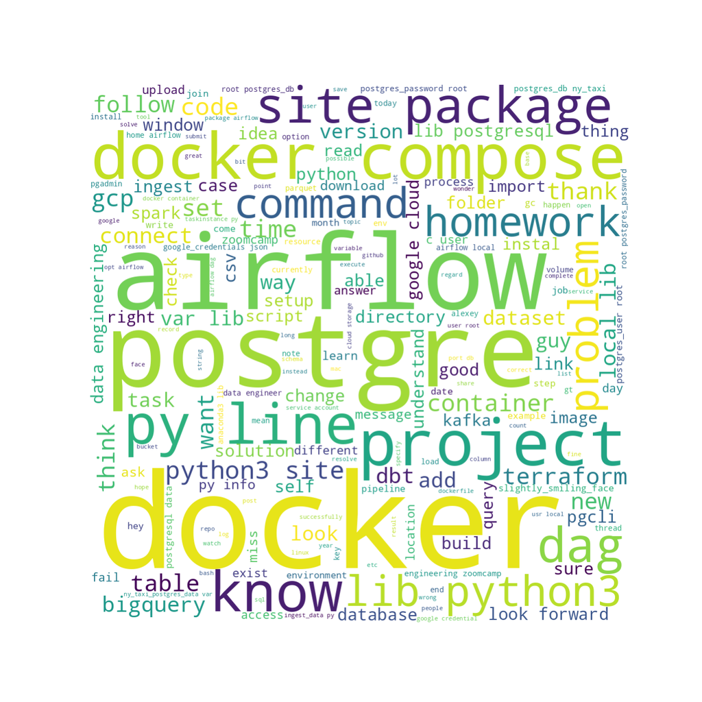

## NetworkGraph: See the community structure

In that section, idea is to build a undirected graph structure to see how connected our data-engineering community is. Later, we can extend the scope to build a directed graph and/or buid a complete Data Talks Club network graph.

### Connnection Through Reactions

[interactive chart not shown]

### Connnection Through Thread Replies

[interactive chart not shown]